# NASA GEO Peru Workshop

## About

Date: 19 August 2019  
By: Patrick Burns, Patrick Jantz, and J. Camilo Fagua  
Contact: Patrick.Burns@nau.edu, Patrick.Jantz@nau.edu, Camilo.Fagua@nau.edu

Acronyms:  
ALS = Airborne Laser Scanner  
GEDI = Global Ecosystem Dynamics Investigation

About the data:  
Airborne lidar data provided by Sustainable Landscapes Brazil - please do NOT redistribute  
Data access: https://www.paisagenslidar.cnptia.embrapa.br/webgis/

Airborne lidar data were simulated to produce GEDI lidar 25 m footprints  
Note: GEDI is scheduled for launch and installation in early December 2018

## Learning Goals

1. Understand the difference between airborne lidar and waveform lidar data
2. Use open-source R packages to visualize and manipulate airborne lidar data in 2D and 3D
3. Visually compare airborne lidar point clouds with simulated GEDI waveforms
4. Produce average relative height profiles and waveforms for area in this example

## Part 0: Libraries

```r
# You need these R packages for the exercise
list.of.packages <- c("rgdal", "rgeos", "raster", "sp", "lidR", "rgl")

# If necessary the 2 lines below will install these packages
new.packages <- list.of.packages[!(list.of.packages %in% installed.packages()[,"Package"])]
if(length(new.packages)>0) install.packages(new.packages)

# Load the packages
library(lidR)
library(raster)
library(sp)
library(rgeos)
```

Package help:  
In R console type: `help('package_name')`

Package documentation from Comprehensive R Archive Network (CRAN):  
* lidR: https://cran.r-project.org/web/packages/lidR/lidR.pdf  
* raster: https://cran.r-project.org/web/packages/raster/raster.pdf  
* sp: https://cran.r-project.org/web/packages/sp/sp.pdf  
* rgeos: https://cran.rstudio.com/web/packages/rgeos/rgeos.pdf

## Part 1: Data Import

First download the data from the dropbox link shared in the workshop

Load in airborne lidar data (this is the file with .laz extension)  
Supply the file path in the variable `lidar_ALS_file`  
Then read in the data with `lidR::readLAS`

```r
lidar_ALS_file='D:/lidar/data/ex1_data/JAML4980C8990.laz'
lidar_ALS_data=lidR::readLAS(files = lidar_ALS_file)
# Specify the projection string associated with the ALS lidar data
projStr = "+proj=utm +zone=20 +south +ellps=GRS80 +towgs84=0,0,0,0,0,0,0 +units=m +no_defs"
```

Load in spaceborne GEDI lidar simulated data (this is the file with .csv extension)  
Note: The GEDI footprints should overlap with airborne lidar data  
Supply the file path in the variable `lidar_GEDI_file`

```r
lidar_GEDI_file='D:/lidar/data/ex1_data/GEDI_L2_embrapa_brazil_keller_2013_32720_subset.csv'
lidar_GEDI_data = read.csv(file = lidar_GEDI_file, header = TRUE)
```

## Part 2: Visualize airborne lidar in 2D

Get the boundary of the airborne lidar data

```r
xMin = lidar_ALS_data@header@PHB[["Min X"]]
xMax = lidar_ALS_data@header@PHB[["Max X"]]
yMin = lidar_ALS_data@header@PHB[["Min Y"]]
yMax = lidar_ALS_data@header@PHB[["Max Y"]]
# Make a polygon from the airborne lidar bounding coordinates
lidar_ALS_box = as(raster::extent(xMin, xMax, yMin, yMax), "SpatialPolygons")
proj4string(lidar_ALS_box) <- projStr
```

Normalization Subtract digital terrain model (DTM) from LiDAR point cloud to create a dataset normalized with the ground at 0

```r
Normal_lidar_ALS_data=lasnormalize(las = lidar_ALS_data,  algorithm = knnidw(k = 6, p = 2))
```

[output not shown]

[output cut: 43 more lines]

[output not shown]

Visualize the airborne lidar data  
Point Density (points per square meter)  
Note: Point Density is a good indicator for data quality

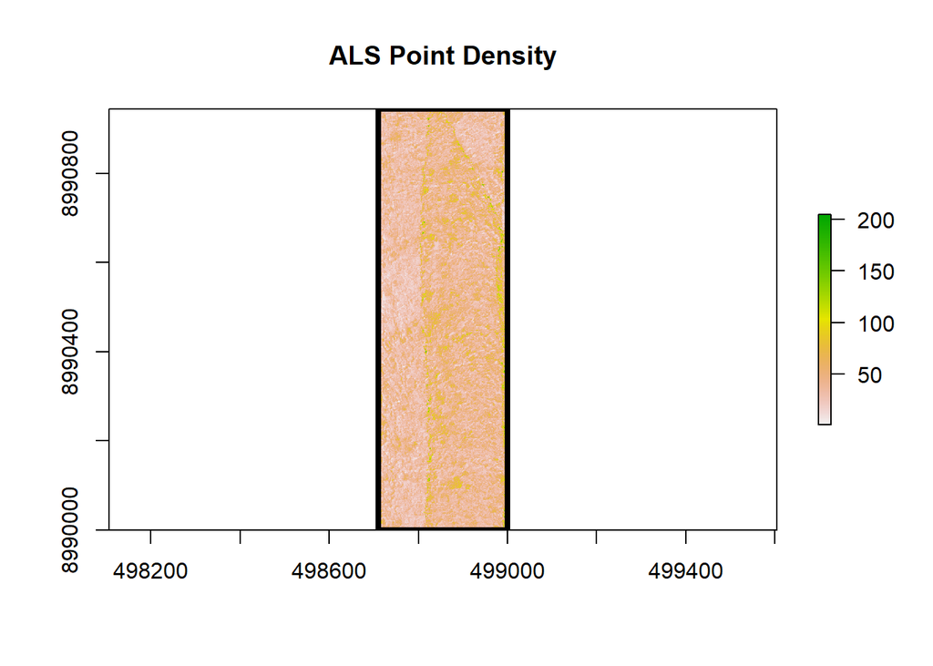

```r
lidar_ALS_dens = lidR::grid_density(las=Normal_lidar_ALS_data, res = 1)
plot(lidar_ALS_dens, main = 'ALS Point Density')
plot(lidar_ALS_box, add=TRUE, border = 'black', lwd = 4)
```

Digital Terrain Model (DTM)  
Note: Digital Terrain Models show the terrain underneath vegetation

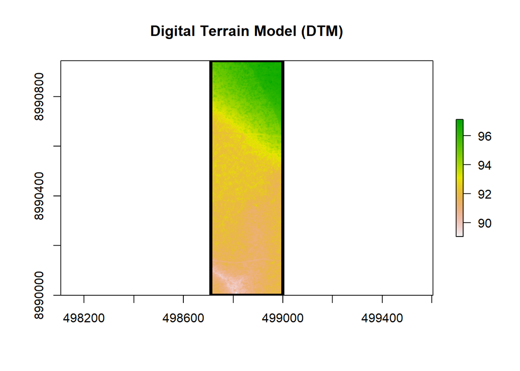

```r
lidar_ALS_dtm = lidR::grid_terrain(las=lidar_ALS_data, res = 1, algorithm = knnidw(k = 6, p = 2))
plot(lidar_ALS_dtm, main = 'Digital Terrain Model (DTM)')
plot(lidar_ALS_box, add=TRUE, border = 'black', lwd = 4)
```

Canopy Height Model (CHM)  
Note: Canopy Height Models show the height of vegetation relative to the ground  
First normalize the points relative to their height above ground. This requires that some points have already been classified as ground

```r
lidR::lasnormalize(las = lidar_ALS_data,  algorithm = knnidw(k = 6, p = 2))
```

[output not shown]

[output cut: 42 more lines]

[output not shown]

```
## class        : LAS (LASF v1.0)
## point format : 1
## memory       : 954.8 Mb
## extent       :498710.8, 499000, 8990000, 8990945 (xmin, xmax, ymin, ymax)
## coord. ref.  : NA
## area         : 273224.3 units² (convex hull)
## points       : 10881839 points
## density      : 39.83 points/units²
## names        : X Y Z gpstime Intensity ReturnNumber NumberOfReturns ScanDirectionFlag EdgeOfFlightline Classification Synthetic_flag Keypoint_flag Withheld_flag ScanAngleRank UserData PointSourceID Zref
```

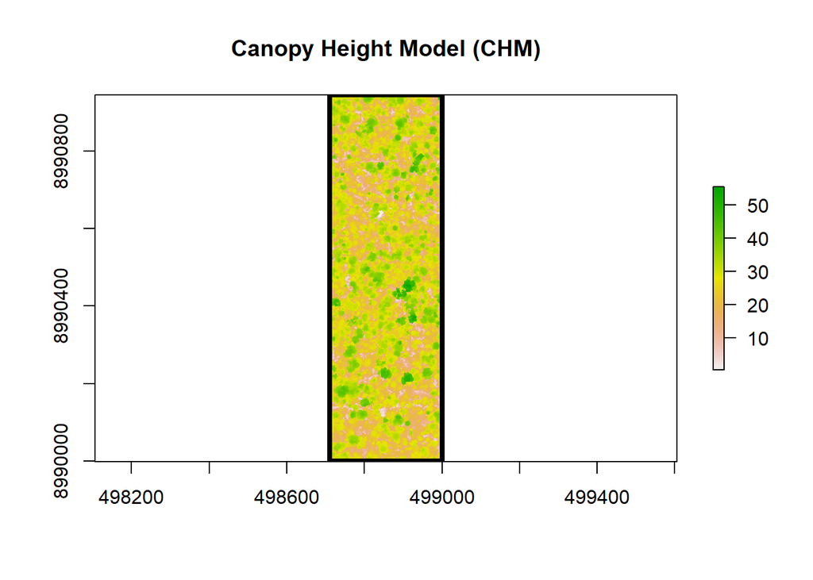

```r
# Now create the canopy height model
lidar_ALS_chm = lidR::grid_canopy(las = Normal_lidar_ALS_data, res = 1, p2r(subcircle = 0.2, na.fill = knnidw(k = 6, p = 2)))
plot(lidar_ALS_chm, main = 'Canopy Height Model (CHM)')
plot(lidar_ALS_box, add=TRUE, border = 'black', lwd = 4)
```

Vertical complexity  
Note:Vertical complexity metrics summarize variation in vertical canopy structure  
lidR allows the user to calculate custom metrics for each grid cell using a pre-defined function:

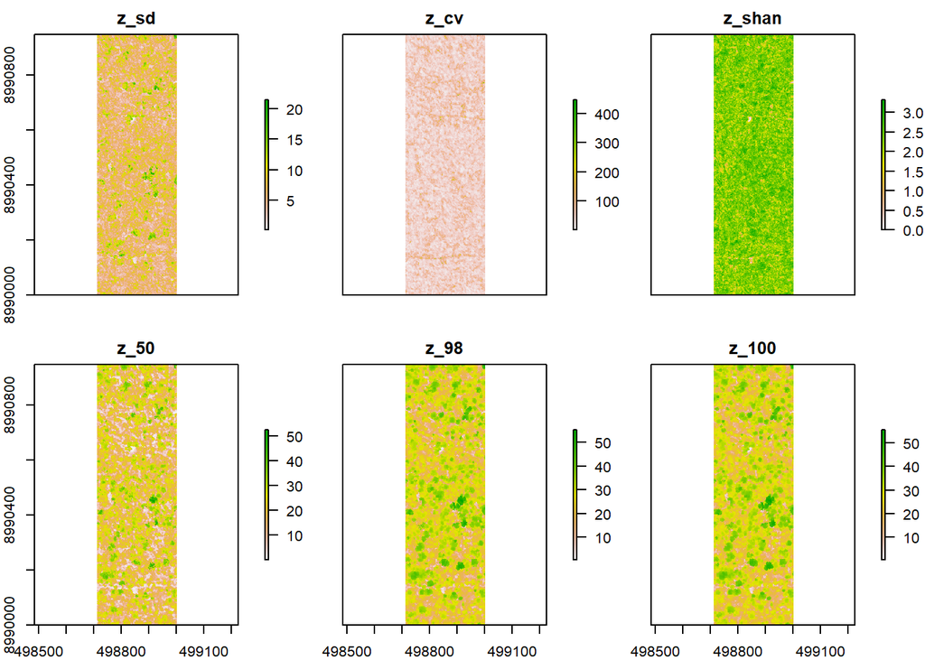

```r
zMetrics = function(z){
  # Calculate Shannon's diversity index on normalized heights
  # First make a histogram
  vertBinSize = 1 # vertical bin width in meters
  vs <- floor(min(z)/10)*10
  vf <- ceiling(max(z)/10)*10
  if (vf-vs==0) {
    shan <- 0
  } else {
    h = hist(z, breaks = seq(vs,vf,vertBinSize), plot=FALSE)
    h_df = data.frame(h$mids)
    h_df$counts = h$counts
    h_df$dens = h$density
    # remove 0 values which will cause an error with Shannon's diversity
    h_df = h_df[h_df$counts>0,]
    # loop through each height bin
    v = vector("numeric", nrow(h_df))
    for (i in 1:nrow(h_df)){
      p = h_df$dens[i]
      s = p*log(p)
      v[i] = s
    }
    # Calculate Shannon's diversity
    shan = -1*sum(v)
    vtop = tail(v, n=1)
    vbottom = v[1]
  }
  # These are the metrics to output
  metrics = list(
    z_sd = sd(z), # standard deviation of normalized heights
    z_cv = cv(z), # coefficient of variation of normalized heights
    z_shan = shan, # Shannon's diversity index
    z_50 = quantile(z, 0.5), # Calculate 50th percentile of heights
    z_98 = quantile(z, 0.98), # Calculate 98th percentile of heights
    z_100 = quantile(z, 1) # Calculate 100th percentile of heights
  )
  return(metrics)
}
# Calculate the custom vertical complexity metrics
lidar_ALS_zComp = lidR::grid_metrics(Normal_lidar_ALS_data, zMetrics(Z), res = 2)
plot(lidar_ALS_zComp)
```

Convert visualizations to raster format

```r
lidar_ALS_dtm_ras = as.raster(lidar_ALS_dtm)
lidar_ALS_chm_ras = as.raster(lidar_ALS_chm)
lidar_ALS_zComp_ras = brick(lidar_ALS_zComp)
```

## Part 3: Visualize airborne lidar in 3D

Try plotting airborne lidar data in 3 dimensions  
First we need to reduce the size of the airborne lidar point cloud

```r
lidar_ALS_box_small = as(raster::extent(xMin, xMin+100, yMin, yMin+100), "SpatialPolygons")
lidar_ALS_data_small = lidR::lasclip(lidar_ALS_data,lidar_ALS_box_small@polygons[[1]]@Polygons[[1]], ofile = "")
```

```r
plot(lidar_ALS_data_small, color = "Classification", trim = 0.98)
```

Color by normalized height  
Note: the plot will open in an interactive window

```r
plot(lidar_ALS_data_small, color = "Z", trim = 0.98)
```

Write out a .las file  
LAS files are the standard industry format. LAZ files are compressed LAS files

```r
lidR::writeLAS(las = lidar_ALS_data_small, file = 'lidar_ALS_data_small.las')
```

There are other options for visualizing the exported point cloud data in 3D. Try the following:  
* plas.io  
* CloudCompare: http://www.cloudcompare.org/

Visulaize a cross-section of airborne lidar points  
Make a 2d (X vs Z) plot for a random sample of points from the airborne lidar data  
Randomly select points from airborne lidar data

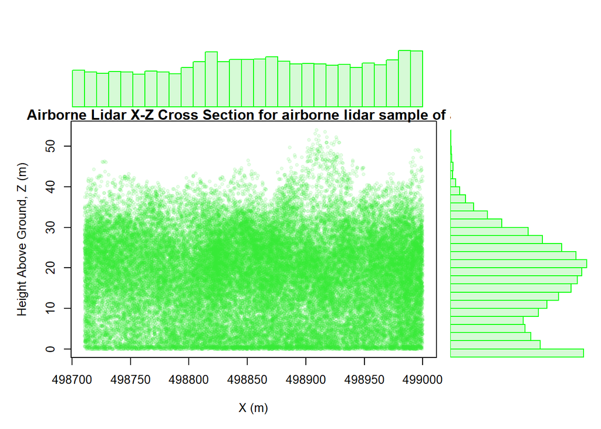

```r
randPts = 50000
lidar_ALS_sample = Normal_lidar_ALS_data@data[sample(1:nrow(Normal_lidar_ALS_data@data), randPts,
                                              replace=FALSE),]
# Next calculate histograms of point distributions
h1 <- hist(lidar_ALS_sample$X, breaks=40, plot=F)
h2 <- hist(lidar_ALS_sample$Z, breaks=20, plot=F)
top <- max(h1$counts, h2$counts)
# Make the 2d plot for the sampled points
oldpar <- par()
par(mar=c(5,5,1,1))
layout(matrix(c(2,0,1,3),2,2,byrow=T),c(3,1), c(1,3))
plot(lidar_ALS_sample$X, lidar_ALS_sample$Z, main = "Airborne Lidar X-Z Cross Section for airborne lidar sample of area",
     pch=20, col = rgb(0.2, 0.9, 0.2, 0.1),
     xlim = c(min(lidar_ALS_sample$X), max(lidar_ALS_sample$X)),
     ylim = c(min(lidar_ALS_sample$Z), max(lidar_ALS_sample$Z)),
     xlab = "X (m)",
     ylab = "Height Above Ground, Z (m)")
par(mar=c(0,5,1,1))
barplot(h1$counts, axes=F,
        xlim = c(findInterval(x = min(lidar_ALS_sample$X), vec = h1$breaks), findInterval(x = max(lidar_ALS_sample$X), vec = h1$breaks)),
        ylim=c(0, top), space=0,
        border='green', col = rgb(0.2, 0.9, 0.2, 0.2))
par(mar=c(5,0,1,1))
barplot(h2$counts, axes=F, xlim=c(0, top),
        ylim = c(findInterval(x = min(lidar_ALS_sample$Z), vec = h2$breaks), findInterval(x = max(lidar_ALS_sample$Z), vec = h2$breaks)),
        space=0, border='green', col = rgb(0.2, 0.9, 0.2, 0.2), horiz=T)
```

# PART 4: Overlap airborne lidar with GEDI footprints

First make the point geometry for the simulated GEDI footprint centers Note: X-Y coordinates are contained in the GEDI simulation (.csv) file

```r
xycols = c("lon","lat")
lidar_GEDI_pts = sp::SpatialPointsDataFrame(coords = lidar_GEDI_data[,xycols], data = lidar_GEDI_data)
# Specify the projection of the points
crs(lidar_GEDI_pts) = projStr
# Only select GEDI points that fall within the lidarboundary
lidar_GEDI_pts = lidar_GEDI_pts[lidar_ALS_box,]
# Make a column of unique IDs for each GEDI observation and add to the data frame
lidar_GEDI_pts$ID = seq(1,nrow(lidar_GEDI_pts),1)
```

Buffer the selected GEDI points to create a circular footprint geometry.  
Specify the buffer radius in meters. Note: GEDI footprints will have a 25m diameter

```r
buffDist = 12.5

lidar_GEDI_Bpts = rgeos::gBuffer(spgeom = lidar_GEDI_pts, width = buffDist, byid = TRUE)
lidar_GEDI_Bpts = SpatialPolygonsDataFrame(lidar_GEDI_Bpts, data = lidar_GEDI_pts@data)
```

Plot the airborne lidar canopy height model with the buffered GEDI points

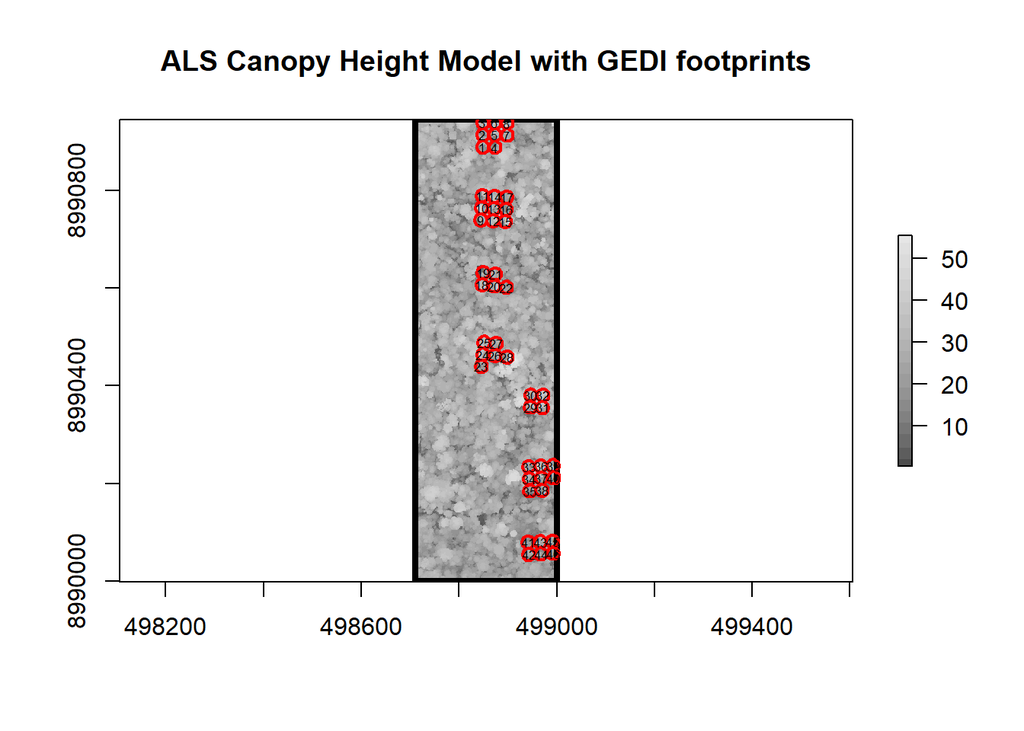

```
##           [,1]    [,2]
##  [1,] 498848.2 8990889
##  [2,] 498848.4 8990914
##  [3,] 498848.5 8990939
##  [4,] 498873.2 8990889
##  [5,] 498873.4 8990914
##  [6,] 498873.5 8990939
##  [7,] 498898.4 8990914
##  [8,] 498898.5 8990939
##  [9,] 498844.6 8990740
## [10,] 498846.1 8990764
## [11,] 498847.6 8990789
## [12,] 498869.6 8990738
## [13,] 498871.1 8990763
## [14,] 498872.6 8990788
```

[output cut: 32 more lines]

```r
plot(lidar_ALS_chm, main = "ALS Canopy Height Model with GEDI footprints", col = grey.colors(20))
plot(lidar_ALS_box, add=TRUE, border = 'black', lwd = 4)
plot(lidar_GEDI_Bpts, pch=16, add = TRUE, border = 'red', lwd =2)
# Label the GEDI footprints with their ID number
rgeos::polygonsLabel(pols = lidar_GEDI_Bpts, labels = lidar_GEDI_Bpts$ID,
                     method = 'centroid', cex = 0.5, col = "black")
```

```r
# The coordinates above are the X,Y center points for the GEDI footprints
```

Now open the GEDI footprints shapefile in QGIS. Also load the airborne lidar DTM, CHM, and vertical complexity rasters in QGIS.

Use the identify tool to select the ID of an intersting GEDI footprint. Use this ID in the next step

## Part 5: Plotting Individual GEDI waveforms

You can try repeating this part of the exercise for different GEDI footprints

GEDI level 2 (L2) simulated data only contain relative height (RH) values  
We need to invert the L2 GEDI relative heights to a waveform

Specify a GEDI footprint ID number in the variable `GEDI_FP_ID` below and run the entire code block

```r
GEDI_FP_ID = '27'

# Specify the re-binning size (in meters) for the GEDI waveform
binSize = 2
# Extract simulated GEDI data for footprint of interest
GEDI_FP = subset(lidar_GEDI_Bpts, ID %in% GEDI_FP_ID)
GEDI_FP_DF = GEDI_FP@data
GEDI_FP_RH = as.data.frame(t(GEDI_FP_DF[ , grepl( "rhReal" , names( GEDI_FP_DF ) ) ]))
colnames(GEDI_FP_RH) = c("RH")
GEDI_FP_RH$binCuml = seq(0,100,2)
GEDI_FP_RH$binPerc = 2
# Re-bin the relative height values into new bins
binsBig = seq(-100, 100, binSize)
rh = vector("numeric")
en = vector("numeric")
interv = vector("numeric")
for (i in 1:(nrow(GEDI_FP_RH)-1)){
    start = length(rh)+1
    binsSmall = seq(GEDI_FP_RH$RH[i], GEDI_FP_RH$RH[i+1], 0.1)
    len = length(binsSmall)
    end = (start+len)-1
    rh[start:end] = binsSmall
    en[start:end] = 2/length(binsSmall)
    interv[start:end] = findInterval(x = rh[start:end], vec = binsBig)
}
# Combine the re-binned data into a data frame
lidar_GEDI_preWave = data.frame(rh, en, interv)
lidar_GEDI_preWave$binsBig = binsBig[interv]
lidar_GEDI_wave = aggregate(lidar_GEDI_preWave$en, by=list(Category=lidar_GEDI_preWave$binsBig), FUN=sum)
colnames(lidar_GEDI_wave) = c("zBin", "percEnergy")
# Extract the airborne lidar points corresponding to this GEDI footprint
GEDI_FP_poly = GEDI_FP@polygons[[1]]@Polygons[[1]]
lidar_ALS_GEDI_FP = lasclip(Normal_lidar_ALS_data, GEDI_FP_poly, ofile = "")
# Make a 2D plot of the points within one GEDI footprint. Plot a cross-section (X vs Z)
# First need to calculate histograms of point distributions for X and Z dimensions
h1 <- hist(lidar_ALS_GEDI_FP@data$X, breaks=10, plot=F)
h2 <- hist(lidar_ALS_GEDI_FP@data$Z, breaks=20, plot=F)
top <- max(h1$counts, h2$counts)
# Make the 2d plot for one footprint

oldpar <- par()
par(mar=c(5,5,1,0))

layout(matrix(c(2,5,6,1,3,4),2,3,byrow=T),c(3,1), c(1,3))
plot(lidar_ALS_GEDI_FP@data$X, lidar_ALS_GEDI_FP@data$Z,
     pch=16, col = rgb(0.2, 0.9, 0.2, 0.2),
     xlim = c(min(lidar_ALS_GEDI_FP@data$X), max(lidar_ALS_GEDI_FP@data$X)),
     ylim = c(min(lidar_ALS_GEDI_FP@data$Z), max(lidar_ALS_GEDI_FP@data$Z)),
     xlab = "X (m)",
     ylab = "Height Above Ground, Z (m)")
par(mar=c(0.1,5,1,0))
barplot(h1$counts, axes=F,
        xlim = c(findInterval(x = min(lidar_ALS_sample$X), vec = h1$breaks), findInterval(x = max(lidar_ALS_sample$X), vec = h1$breaks)),
        ylim=c(0, top), space=0, border='green', col = rgb(0.2, 0.9, 0.2, 0.2),
        main = paste0("Airborne lidar vs GEDI lidar - Footprint ", GEDI_FP_ID))
par(mar=c(5,1,0,1))
barplot(h2$counts, axes=F, xlim=c(0, top),
        ylim = c(findInterval(x = min(lidar_ALS_sample$Z), vec = h2$breaks), findInterval(x = max(lidar_ALS_sample$Z), vec = h2$breaks)),
        space=0, border='green', col = rgb(0.2, 0.9, 0.2, 0.2), horiz=T)
par(mar=c(5,1,1,1))
plot(lidar_GEDI_wave$zBin~lidar_GEDI_wave$percEnergy, axes = T,
     xlim = c(0, 15),
     ylim = c(min(lidar_ALS_GEDI_FP@data$Z), max(lidar_ALS_GEDI_FP@data$Z)),
     type = 'l', col = "red", lwd = 2,
     main = "GEDI Waveform", xlab = "Percent Energy")
par(mar=c(3,3,3,3))

image(lidar_ALS_chm, axes=T, ann=F, asp=1, col = grey.colors(20),
      xlim = c(GEDI_FP$lon-50, GEDI_FP$lon+50), ylim = c(GEDI_FP$lat-50, GEDI_FP$lat+50))
text(GEDI_FP$lon+45, GEDI_FP$lat+40,"CHM", col = 'black', cex = 1)
plot(lidar_GEDI_Bpts, pch=16, add = TRUE, border = 'black', lwd =1)
rgeos::polygonsLabel(pols = GEDI_FP, labels = GEDI_FP$ID,
                     method = 'centroid', cex = 0.5, col = "black")
```

```
##          [,1]    [,2]
## [1,] 498875.8 8990487
```

```r
plot(GEDI_FP, pch=16, add = TRUE, border = 'red', lwd =2)
par(mar=c(3,3,3,3))
image(lidar_ALS_zComp$z_shan, axes=T, ann=F, asp=1, col = topo.colors(20),
      xlim = c(GEDI_FP$lon-50, GEDI_FP$lon+50), ylim = c(GEDI_FP$lat-50, GEDI_FP$lat+50))
text(GEDI_FP$lon+45, GEDI_FP$lat+40,"Shannon's", col = 'black', cex = 1)
plot(lidar_GEDI_Bpts, pch=16, add = TRUE, border = 'black', lwd =1)
rgeos::polygonsLabel(pols = GEDI_FP, labels = GEDI_FP$ID,
                     method = 'centroid', cex = 0.5, col = "black")
```

```
##          [,1]    [,2]
## [1,] 498875.8 8990487
```

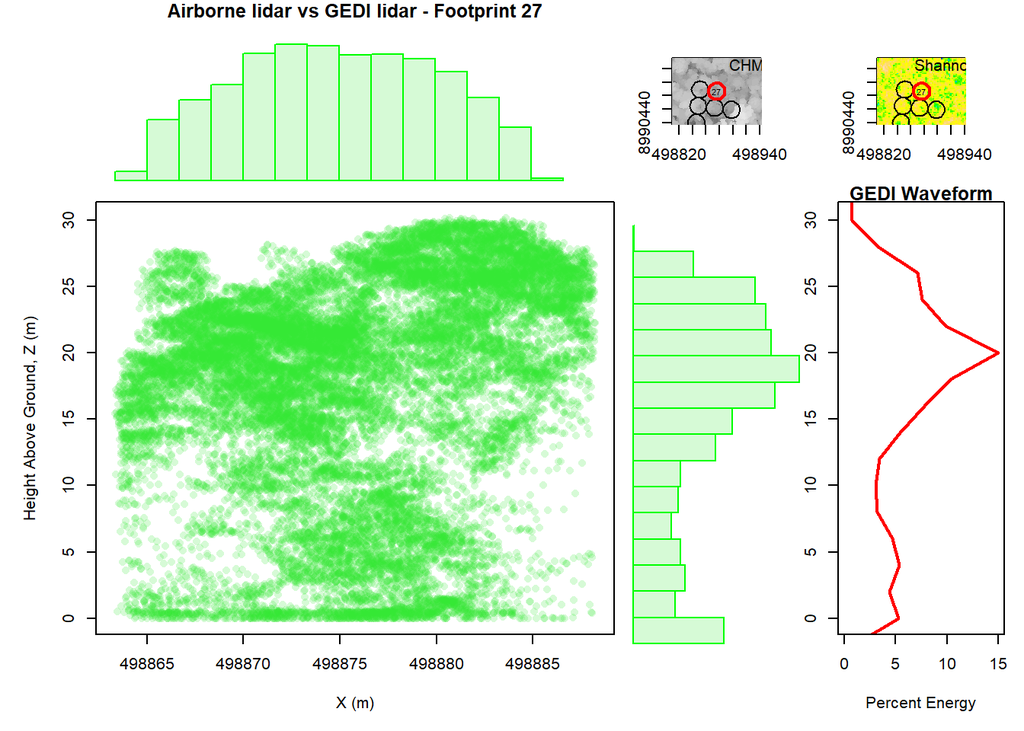

```r
plot(GEDI_FP, pch=16, add = TRUE, border = 'red', lwd =2)
```

## Part 6: Plotting Average GEDI waveforms

Plot the average waveform for this block of airborne lidar data  
Extract all relative height metrics from the GEDI data

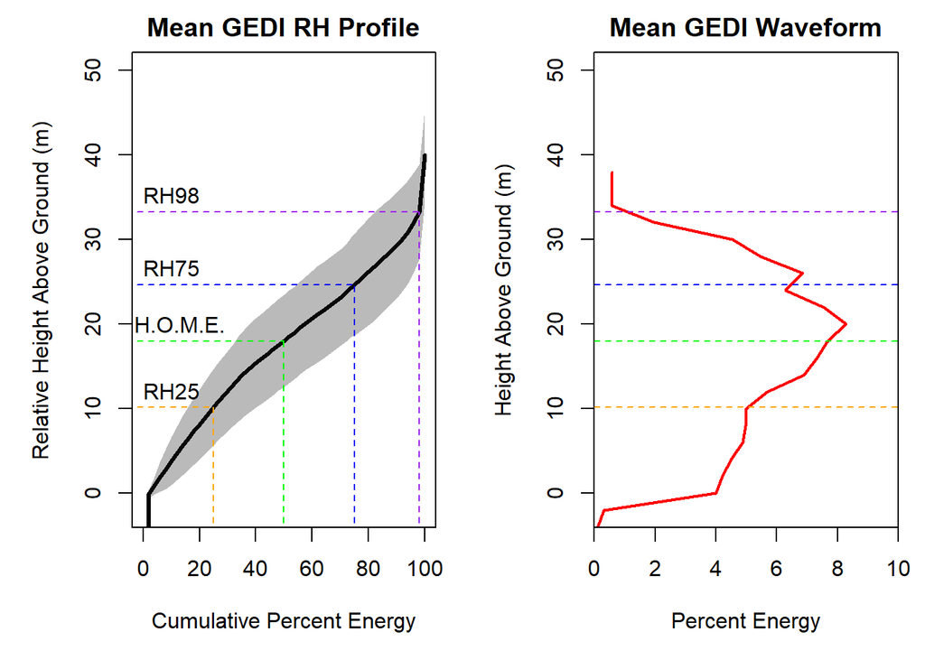

```r
GEDI_All_RH = as.data.frame(t(lidar_GEDI_Bpts@data[ , grepl( "rhReal" , names( lidar_GEDI_Bpts@data ) ) ]))
GEDI_All_RHmean = as.data.frame(rowMeans(GEDI_All_RH))
colnames(GEDI_All_RHmean) = c("RH")
GEDI_All_RHmean$stdev = apply(GEDI_All_RH[,1:ncol(GEDI_All_RH)],1,sd)
GEDI_All_RHmean$binCuml = seq(0,100,2)
GEDI_All_RHmean$binPerc = 2
# Re-bin the relative height values into new bins
binsBig = seq(-100, 100, binSize)
rh = vector("numeric")
en = vector("numeric")
interv = vector("numeric")
for (i in 1:(nrow(GEDI_All_RHmean)-1)){
  start = length(rh)+1
  binsSmall = seq(GEDI_All_RHmean$RH[i], GEDI_All_RHmean$RH[i+1], 0.1)
  len = length(binsSmall)
  end = (start+len)-1
  rh[start:end] = binsSmall
  en[start:end] = 2/length(binsSmall)
  interv[start:end] = findInterval(x = rh[start:end], vec = binsBig)
}
# Combine the re-binned data into a data frame
lidar_GEDI_mean_preWave = data.frame(rh, en, interv)
lidar_GEDI_mean_preWave$binsBig = binsBig[interv]
lidar_GEDI_mean_wave = aggregate(lidar_GEDI_mean_preWave$en, by=list(Category=lidar_GEDI_mean_preWave$binsBig), FUN=sum)
colnames(lidar_GEDI_mean_wave) = c("zBin", "percEnergy")
# Make a plot of the average relative height values for this area
oldpar <- par()
par(mar=c(5,5,2,1))
layout(matrix(c(1,2),1,2,byrow=T),c(1,1), c(1,1))
plot(GEDI_All_RHmean$RH~GEDI_All_RHmean$binCuml,
     main = "Mean GEDI RH Profile", type = 'l', lwd = 3,
     xlim = c(0,100), ylim = c(-2,50), xlab = "Cumulative Percent Energy",
     ylab = "Relative Height Above Ground (m)")
# Plot a polygon corresponding to 1 standard deviation around the RH profile
polyX = c(seq(0,100,2),rev(seq(0,100,2)))
polyY = c((GEDI_All_RHmean$RH-GEDI_All_RHmean$stdev), rev((GEDI_All_RHmean$RH+GEDI_All_RHmean$stdev)))
polygon(polyX, polyY, col = rgb(0.1,0.1,0.1,0.3), border = NA)
# Plot lines corresponding to different relative heights
RH25 = (GEDI_All_RHmean$RH[GEDI_All_RHmean$binCuml==24]+GEDI_All_RHmean$RH[GEDI_All_RHmean$binCuml==26])/2
lines(c(25,25), c(-10,RH25), lty = "dashed", type = 'l', col = "orange")
lines(c(-10,25), c(RH25,RH25), lty = "dashed", col = "orange")
text(10,RH25+2,"RH25")
HOME = GEDI_All_RHmean$RH[GEDI_All_RHmean$binCuml==50]
lines(c(50,50), c(-10,HOME), lty = "dashed", type = 'l', col = "green")
lines(c(-10,50), c(HOME,HOME), lty = "dashed", col = "green")
text(13,HOME+2,"H.O.M.E.")
RH75 = (GEDI_All_RHmean$RH[GEDI_All_RHmean$binCuml==74]+GEDI_All_RHmean$RH[GEDI_All_RHmean$binCuml==76])/2
lines(c(75,75), c(-10,RH75), lty = "dashed", type = 'l', col = "blue")
lines(c(-10,75), c(RH75,RH75), lty = "dashed", col = "blue")
text(10,RH75+2,"RH75")
RH98 = GEDI_All_RHmean$RH[GEDI_All_RHmean$binCuml==98]
lines(c(98,98), c(-10,RH98), lty = "dashed", type = 'l', col = "purple")
lines(c(-10,98), c(RH98,RH98), lty = "dashed", col = "purple")
text(10,RH98+2,"RH98")
# Make a plot of average waveform for this area
plot(lidar_GEDI_mean_wave$zBin~lidar_GEDI_mean_wave$percEnergy,
     main = "Mean GEDI Waveform",
     xlab = "Percent Energy", ylab = "Height Above Ground (m)",
     xlim = c(0,10), ylim = c(-2,50), xaxs="i",
     type = 'l', lwd = 2, col = "red")
abline(h = RH25, lty = "dashed", col = "orange")
abline(h = HOME, lty = "dashed", col = "green")
abline(h = RH75, lty = "dashed", col = "blue")
abline(h = RH98, lty = "dashed", col = "purple")
```